# scRNA-Seq Lab

Kaarunya Nachimuthu

2024-04-30

From Bioconductor

```r
BiocManager::install("AnnotationHub")
BiocManager::install("ensembldb")
BiocManager::install("multtest")
BiocManager::install("glmGamPoi")
```

Loading R libraries

```r
# Load libraries
library(SingleCellExperiment)
library(Seurat)
library(tidyverse)
library(Matrix)
library(RCurl)
library(scales)
```

```r
library(cowplot)
library(AnnotationHub)
library(ensembldb)
```

Create directories

```r
data_dir <- "C:/Users/kaaru/Desktop/Assignment/IB2/scRNA/single_cell_rnaseq/single_cell_rnaseq"
plot_dir <- "C:/Users/kaaru/Desktop/Assignment/IB2/scRNA/single_cell_rnaseq/single_cell_rnaseq/figures"
```

# Read dataset

```r
# How to read in 10X data for a single sample (output is a sparse matrix)
ctrl_counts <- Read10X(data.dir = "data/ctrl_raw_feature_bc_matrix")

# Turn count matrix into a Seurat object (output is a Seurat object)
ctrl <- CreateSeuratObject(counts = ctrl_counts,
                           min.features = 100)
```

```r
# Explore the metadata
head(ctrl@meta.data)
```

```
##                     orig.ident nCount_RNA nFeature_RNA
## AAACATACAATGCC-1 SeuratProject       2344          874
## AAACATACATTTCC-1 SeuratProject       3125          896
## AAACATACCAGAAA-1 SeuratProject       2578          725
## AAACATACCAGCTA-1 SeuratProject       3261          979
## AAACATACCATGCA-1 SeuratProject        746          362
## AAACATACCTCGCT-1 SeuratProject       3519          866
```

```r
# Create a Seurat object for each sample
for (file in c("ctrl_raw_feature_bc_matrix", "stim_raw_feature_bc_matrix")){
        seurat_data <- Read10X(data.dir = paste0("data/", file))
        seurat_obj <- CreateSeuratObject(counts = seurat_data,
                                         min.features = 100,
                                         project = file)
        assign(file, seurat_obj)
}
```

```r
# Check the metadata in the new Seurat objects
head(ctrl_raw_feature_bc_matrix@meta.data)
```

```
##                                  orig.ident nCount_RNA nFeature_RNA
## AAACATACAATGCC-1 ctrl_raw_feature_bc_matrix       2344          874
## AAACATACATTTCC-1 ctrl_raw_feature_bc_matrix       3125          896
## AAACATACCAGAAA-1 ctrl_raw_feature_bc_matrix       2578          725
## AAACATACCAGCTA-1 ctrl_raw_feature_bc_matrix       3261          979
## AAACATACCATGCA-1 ctrl_raw_feature_bc_matrix        746          362
## AAACATACCTCGCT-1 ctrl_raw_feature_bc_matrix       3519          866
```

```r
head(stim_raw_feature_bc_matrix@meta.data)
```

```
##                                  orig.ident nCount_RNA nFeature_RNA
## AAACATACCAAGCT-1 stim_raw_feature_bc_matrix       1221          606
## AAACATACCCCTAC-1 stim_raw_feature_bc_matrix       1782          807
## AAACATACCCGTAA-1 stim_raw_feature_bc_matrix       1451          605
## AAACATACCCTCGT-1 stim_raw_feature_bc_matrix       1549          747
## AAACATACGAGGTG-1 stim_raw_feature_bc_matrix       1303          558
## AAACATACGCGAAG-1 stim_raw_feature_bc_matrix       5445         1330
```

```r
# Create a merged Seurat object
merged_seurat <- merge(x = ctrl_raw_feature_bc_matrix,
                       y = stim_raw_feature_bc_matrix,
                       add.cell.id = c("ctrl", "stim"))
```

```r
# Check that the merged object has the appropriate sample-specific prefixes
head(merged_seurat@meta.data)
```

```
##                                       orig.ident nCount_RNA nFeature_RNA
## ctrl_AAACATACAATGCC-1 ctrl_raw_feature_bc_matrix       2344          874
## ctrl_AAACATACATTTCC-1 ctrl_raw_feature_bc_matrix       3125          896
## ctrl_AAACATACCAGAAA-1 ctrl_raw_feature_bc_matrix       2578          725
## ctrl_AAACATACCAGCTA-1 ctrl_raw_feature_bc_matrix       3261          979
## ctrl_AAACATACCATGCA-1 ctrl_raw_feature_bc_matrix        746          362
## ctrl_AAACATACCTCGCT-1 ctrl_raw_feature_bc_matrix       3519          866
```

```r
tail(merged_seurat@meta.data)
```

```
##                                       orig.ident nCount_RNA nFeature_RNA
## stim_TTTGCATGCGACAT-1 stim_raw_feature_bc_matrix        620          295
## stim_TTTGCATGCTAAGC-1 stim_raw_feature_bc_matrix       1641          545
## stim_TTTGCATGGGACGA-1 stim_raw_feature_bc_matrix       1233          518
## stim_TTTGCATGGTGAGG-1 stim_raw_feature_bc_matrix       1084          469
## stim_TTTGCATGGTTTGG-1 stim_raw_feature_bc_matrix        818          432
## stim_TTTGCATGTCTTAC-1 stim_raw_feature_bc_matrix       1104          438
```

Generating Quality metrics

```r
# Explore merged metadata
View(merged_seurat@meta.data)
```

Novelty score

```r
# Add number of genes per UMI for each cell to metadata
merged_seurat$log10GenesPerUMI <- log10(merged_seurat$nFeature_RNA) / log10(merged_seurat$nCount_RNA)
```

Mitochondrial Ratio

```r
# Compute percent mito ratio
merged_seurat$mitoRatio <- PercentageFeatureSet(object = merged_seurat, pattern = "^MT-")
merged_seurat$mitoRatio <- merged_seurat@meta.data$mitoRatio / 100
```

Additional metadata columns

```r
# Create metadata dataframe
metadata <- merged_seurat@meta.data
```

```r
# Add cell IDs to metadata
metadata$cells <- rownames(metadata)
```

```r
# Create sample column
metadata$sample <- NA
metadata$sample[which(str_detect(metadata$cells, "^ctrl_"))] <- "ctrl"
metadata$sample[which(str_detect(metadata$cells, "^stim_"))] <- "stim"
```

```r
# Rename columns
metadata <- metadata %>%
        dplyr::rename(seq_folder = orig.ident,
                      nUMI = nCount_RNA,
                      nGene = nFeature_RNA)
```

Saving the updated metadata to our seurat object

```r
# Add metadata back to Seurat object
merged_seurat@meta.data <- metadata

# Create .RData object to load at any time
save(merged_seurat, file="data/merged_filtered_seurat.RData")
```

Assessing the quality metrics Cell counts

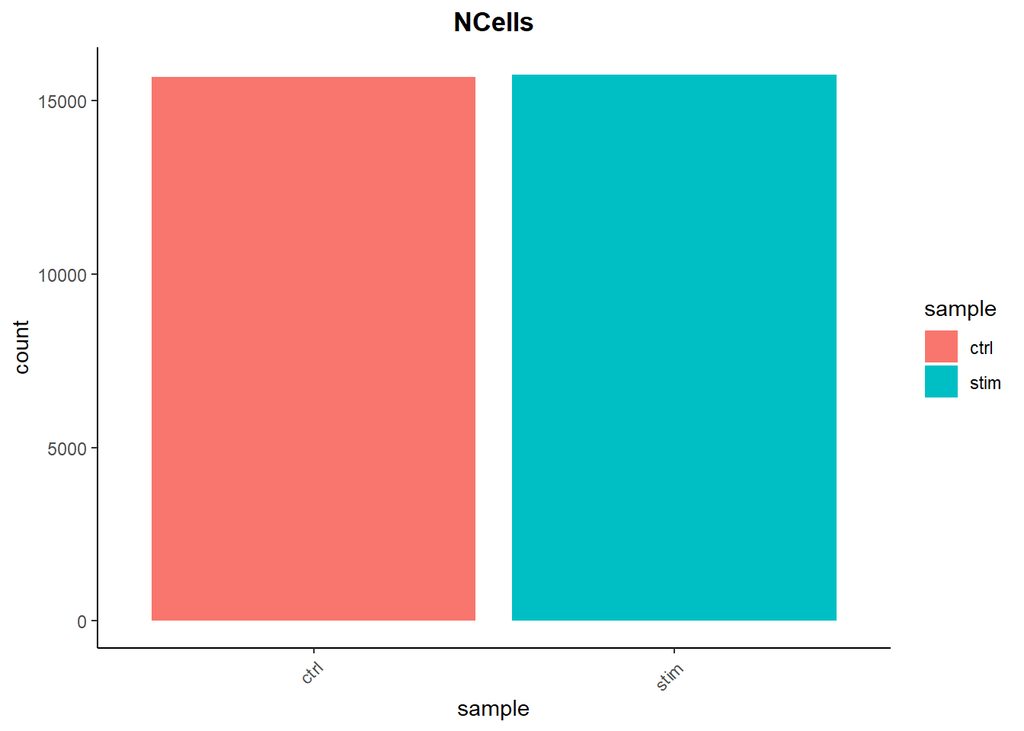

```r
# Visualize the number of cell counts per sample
metadata %>%
    ggplot(aes(x=sample, fill=sample)) +
    geom_bar() +
    theme_classic() +
    theme(axis.text.x = element_text(angle = 45, vjust = 1, hjust=1)) +
    theme(plot.title = element_text(hjust=0.5, face="bold")) +
    ggtitle("NCells")
```

UMI counts per cell

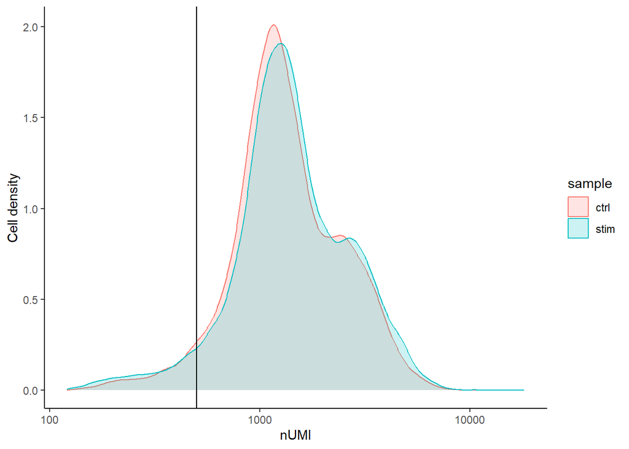

```r
# Visualize the number UMIs/transcripts per cell
metadata %>%
    ggplot(aes(color=sample, x=nUMI, fill= sample)) +
    geom_density(alpha = 0.2) +
    scale_x_log10() +
    theme_classic() +
    ylab("Cell density") +
    geom_vline(xintercept = 500)
```

Genes detected per cell

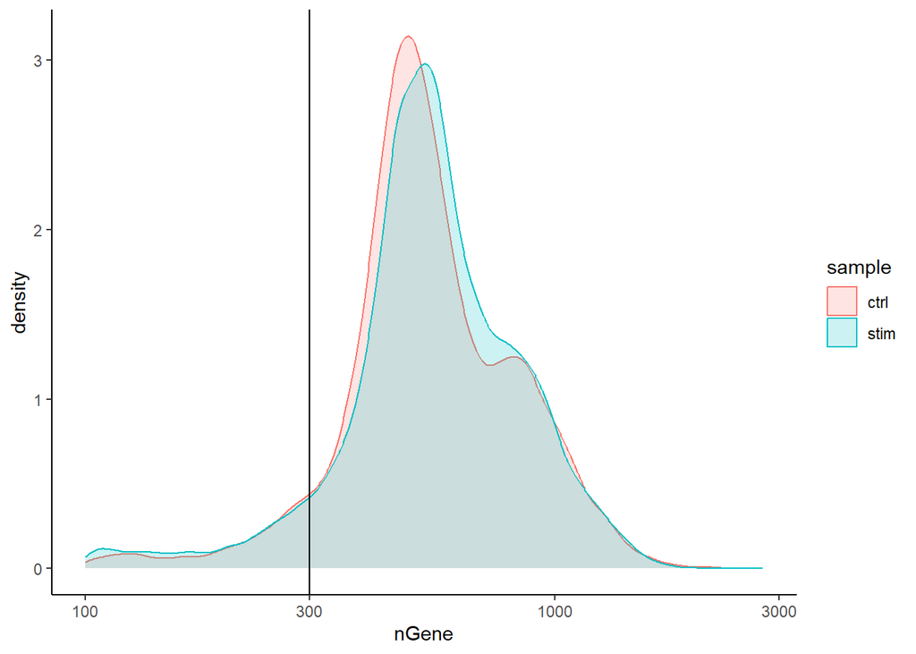

```r
# Visualize the distribution of genes detected per cell via histogram
metadata %>%
    ggplot(aes(color=sample, x=nGene, fill= sample)) +
    geom_density(alpha = 0.2) +
    theme_classic() +
    scale_x_log10() +
    geom_vline(xintercept = 300)
```

Complexity

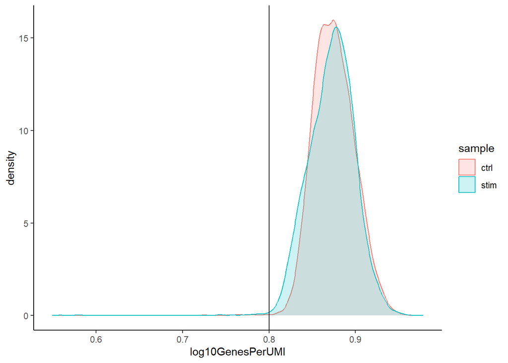

```r
# Visualize the overall complexity of the gene expression by visualizing the genes detected per UMI (novelty score)
metadata %>%
    ggplot(aes(x=log10GenesPerUMI, color = sample, fill=sample)) +
    geom_density(alpha = 0.2) +
    theme_classic() +
    geom_vline(xintercept = 0.8)
```

Mitochondrial counts ratio

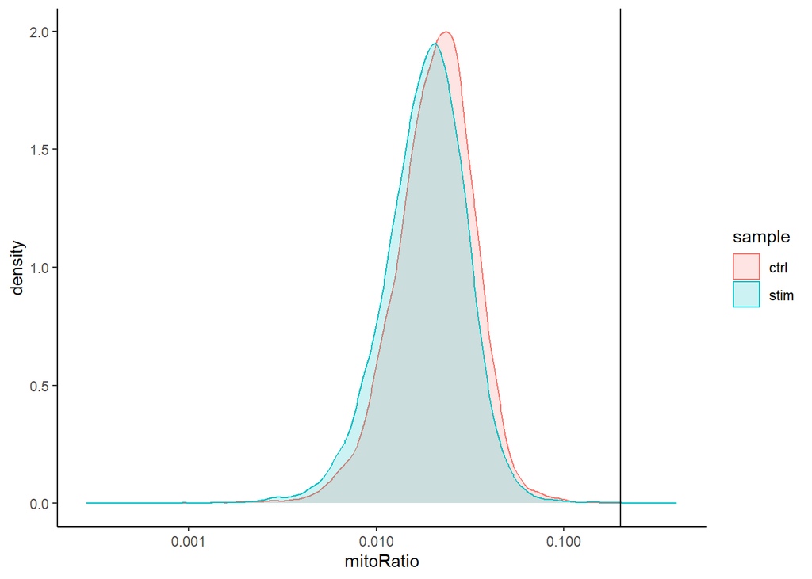

```r
# Visualize the distribution of mitochondrial gene expression detected per cell
metadata %>%
    ggplot(aes(color=sample, x=mitoRatio, fill=sample)) +
    geom_density(alpha = 0.2) +
    scale_x_log10() +
    theme_classic() +
    geom_vline(xintercept = 0.2)
```

Joint Filtering effects

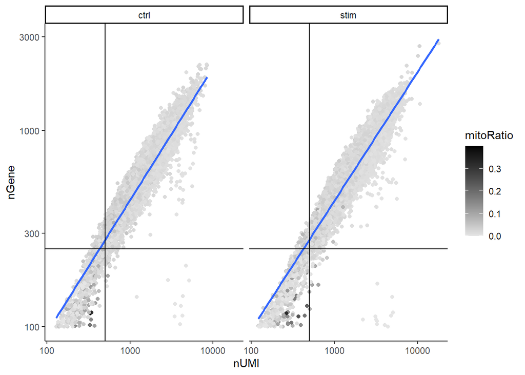

```r
# Visualize the correlation between genes detected and number of UMIs and determine whether strong presence of cells with low numbers of genes/UMIs
metadata %>%
    ggplot(aes(x=nUMI, y=nGene, color=mitoRatio)) +
    geom_point() +
    scale_colour_gradient(low = "gray90", high = "black") +
    stat_smooth(method=lm) +
    scale_x_log10() +
    scale_y_log10() +
    theme_classic() +
    geom_vline(xintercept = 500) +
    geom_hline(yintercept = 250) +
    facet_wrap(~sample)
```

Filtering Cell-level filtering

```r
# Filter out low quality cells using selected thresholds - these will change with experiment
filtered_seurat <- subset(x = merged_seurat,
                         subset= (nUMI >= 500) &
                           (nGene >= 250) &
                           (log10GenesPerUMI > 0.80) &
                           (mitoRatio < 0.20))
```

Gene-level filtering

```r
# Join layers first
filtered_seurat <- JoinLayers(filtered_seurat)
# Now you can access the combined counts
counts <- LayerData(filtered_seurat, layer = "counts")

# Extract counts
counts <- GetAssayData(object = filtered_seurat, layer = "counts")
# Output a logical matrix specifying for each gene on whether or not there are more than zero counts per cell
nonzero <- counts > 0
```

```r
# Sums all TRUE values and returns TRUE if more than 10 TRUE values per gene
keep_genes <- Matrix::rowSums(nonzero) >= 10

# Only keeping those genes expressed in more than 10 cells
filtered_counts <- counts[keep_genes, ]
```

```r
# Reassign to filtered Seurat object
filtered_seurat <- CreateSeuratObject(filtered_counts, meta.data = filtered_seurat@meta.data)
```

Re-assess QC metrics

```r
 # Save filtered subset to new metadata
 metadata_clean <- filtered_seurat@meta.data
```

Saving filtered cells

```r
# Create .RData object to load at any time
save(filtered_seurat, file="data/seurat_filtered.RData")
```

Single-cell RNA-seq - normalization

```r
# Load libraries
library(Seurat)
library(tidyverse)
library(RCurl)
library(cowplot)
```

```r
seurat_phase <- NormalizeData(filtered_seurat)
```

```
## Normalizing layer: counts
```

```r
# Load cell cycle markers
load("data/cycle.rda")

# Score cells for cell cycle
seurat_phase <- CellCycleScoring(seurat_phase,
                                 g2m.features = g2m_genes,
                                 s.features = s_genes)
# View cell cycle scores and phases assigned to cells
View(seurat_phase@meta.data)
```

```r
# Identify the most variable genes
seurat_phase <- FindVariableFeatures(seurat_phase,
                     selection.method = "vst",
                     nfeatures = 2000,
                     verbose = FALSE)

# Scale the counts
seurat_phase <- ScaleData(seurat_phase)
# Perform PCA
seurat_phase <- RunPCA(seurat_phase)
```

```
## PC_ 1
## Positive:  CCR7, LTB, TRBC1, ITM2A, TRAT1, IL32, CCL5, NKG7, ALOX5AP, GZMB
##     GNLY, CST7, CREM, CD27, PASK, SNHG8, BIRC3, CD8A, MYC, GPR171
##     CD8B, GZMH, KLRD1, ADTRP, PRF1, NOP58, FGFBP2, CXCR3, TIGIT, SESN3
## Negative:  C15orf48, TYROBP, CST3, FCER1G, SOD2, TYMP, ANXA5, TIMP1, KYNU, LGALS3
##     FTL, FCN1, CD63, LGALS1, CTSB, APOBEC3A, IGSF6, LYZ, S100A4, ANXA2
##     SPI1, CCL2, PSAP, NPC2, NINJ1, CD68, S100A11, CTSL, MAFB, IDO1
## PC_ 2
## Positive:  CXCL8, CLEC5A, CD14, VCAN, S100A8, IER3, IL1B, MARCKSL1, PID1, CD9
##     PLAUR, S100A9, THBS1, OSM, PHLDA1, SLC7A11, PPIF, GAPT, AC245128.3, INSIG1
##     MCEMP1, ENG, CXCL3, MGST1, OLR1, LIMS1, GAPDH, SMIM25, PFN1, FTH1
## Negative:  ISG15, IFIT3, IFIT1, ISG20, LY6E, TNFSF10, IFIT2, MX1, IFI6, RSAD2
##     CXCL10, OAS1, CXCL11, IFITM3, MT2A, USP18, IRF7, OASL, IDO1, TNFSF13B
##     IL1RN, CCL8, EPSTI1, IFITM2, SAMD9L, GBP1, APOBEC3A, PLSCR1, CMPK2, DDX58
## PC_ 3
## Positive:  IGHM, CD79A, HLA-DQA1, IGKC, CD74, CD83, HLA-DQB1, HLA-DRA, MS4A1, HLA-DRB1
##     HLA-DPA1, HLA-DPB1, IRF8, CCR7, SYNGR2, HERPUD1, IGLC2, ID3, IGHD, BLNK
##     HLA-DMA, HVCN1, HSP90AB1, RUBCNL, CD79B, BANK1, TCL1A, HLA-DMB, REL, MIR155HG
## Negative:  NKG7, GNLY, CCL5, ANXA1, GZMB, PRF1, KLRD1, GZMH, CST7, GZMA
##     FGFBP2, CLIC3, CTSW, TRBC1, FASLG, OASL, IL32, CD8A, HOPX, MT2A
##     KLRC1, SH3BGRL3, SPON2, CCL4, CXCR3, C12orf75, GCHFR, SH2D1B, TRGC2, LAG3
## PC_ 4
## Positive:  NKG7, GZMB, GNLY, CCL5, CST7, PRF1, KLRD1, CLIC3, GZMA, GZMH
##     FGFBP2, CTSW, FASLG, HOPX, KLRC1, HLA-DPB1, HLA-DPA1, CD74, C12orf75, SH2D1B
##     IGFBP7, SPON2, TNFRSF18, ID2, HLA-DQA1, CXCR3, RAMP1, CD38, TRDC, GCHFR
## Negative:  LTB, CCR7, TRAT1, ADTRP, TSHZ2, PASK, SOCS3, CMTM8, CD27, CCL8
##     CCL2, MYC, CTSL, TARBP1, NELL2, CCL7, SNHG8, IL1RN, MAL, ITM2A
##     SESN3, HPSE, SOD2, IL23A, FBLN7, SCML1, APOBEC3A, TXNIP, LPAR6, S100A9
## PC_ 5
## Positive:  VMO1, FCGR3A, MS4A4A, MS4A7, CXCL16, PPM1N, LST1, PECAM1, SMPDL3A, JPT1
##     AIF1, CH25H, SERPINA1, CDKN1C, LRRC25, CASP5, PLAC8, VASP, GBP5, SMIM25
##     RGS19, LILRA5, HCAR3, C3AR1, CD86, PILRA, CFD, IGHM, SCIMP, STXBP2
## Negative:  LMNA, HSPA1A, HSPE1, FABP5, TXN, CACYBP, HSPA1B, SRSF2, CCL7, HSPB1
##     HSPH1, GADD45B, CCL2, HSPD1, HSP90AB1, PLA2G7, HSPA5, HSP90AA1, GPR183, CCL8
##     TCP1, SRSF7, SDS, DNAJB4, DNAJB1, ZFAND2A, NOP58, MIR155HG, NR4A2, TPM4
```

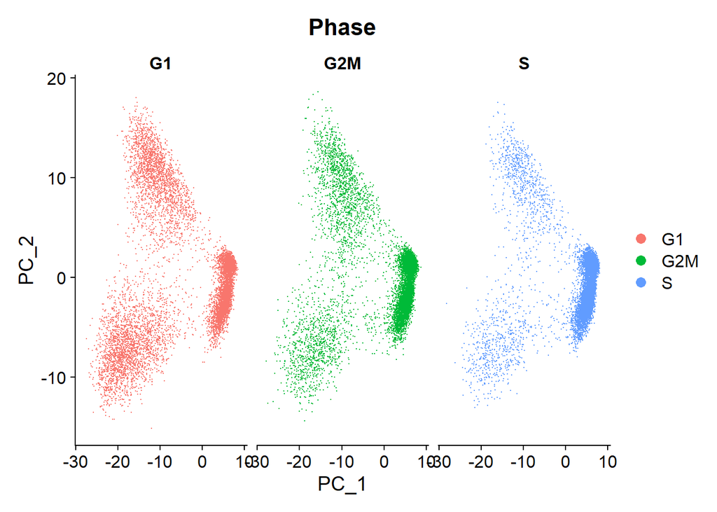

```r
# Plot the PCA colored by cell cycle phase
DimPlot(seurat_phase,
        reduction = "pca",
        group.by= "Phase",
        split.by = "Phase")
```

```r
# Check quartile values
summary(seurat_phase@meta.data$mitoRatio)
```

```
##    Min. 1st Qu.  Median    Mean 3rd Qu.    Max.
## 0.00000 0.01438 0.01993 0.02139 0.02669 0.14464
```

```r
# Turn mitoRatio into categorical factor vector based on quartile values
seurat_phase@meta.data$mitoFr <- cut(seurat_phase@meta.data$mitoRatio,
                   breaks=c(-Inf, 0.0144, 0.0199, 0.0267, Inf),
                   labels=c("Low","Medium","Medium high", "High"))
```

Normalization and regressing out sources of unwanted variation using SCTransform

```r
# SCTranform
seurat_phase <- SCTransform(seurat_phase, vars.to.regress = c("mitoRatio"))
```

```
## Running SCTransform on assay: RNA
```

```
## Running SCTransform on layer: counts
```

```
## vst.flavor='v2' set. Using model with fixed slope and excluding poisson genes.
```

```
## Variance stabilizing transformation of count matrix of size 14065 by 29629
```

```
## Model formula is y ~ log_umi
```

```
## Get Negative Binomial regression parameters per gene
```

```
## Using 2000 genes, 5000 cells
```

```
## Found 473 outliers - those will be ignored in fitting/regularization step
```

```
## Second step: Get residuals using fitted parameters for 14065 genes
```

```
## Computing corrected count matrix for 14065 genes
```

```
## Wall clock passed: Time difference of 6.296919 mins
```

```
## Determine variable features
```

```
## Centering data matrix
```

```
## Getting residuals for block 1(of 6) for counts dataset
```

```
## Getting residuals for block 2(of 6) for counts dataset
```

```
## Getting residuals for block 3(of 6) for counts dataset
```

```
## Getting residuals for block 4(of 6) for counts dataset
```

```
## Getting residuals for block 5(of 6) for counts dataset
```

```
## Getting residuals for block 6(of 6) for counts dataset
```

```
## Centering data matrix
```

```
## Finished calculating residuals for counts
```

```
## Set default assay to SCT
```

```r
# Split seurat object by condition to perform cell cycle scoring and SCT on all samples
split_seurat <- SplitObject(seurat_phase, split.by = "sample")

split_seurat <- split_seurat[c("ctrl", "stim")]
```

```r
options(future.globals.maxSize = 4000 * 1024^2)



for (i in 1:length(split_seurat)) {
    split_seurat[[i]] <- SCTransform(split_seurat[[i]], vars.to.regress = c("mitoRatio"), vst.flavor = "v2")
    }
```

```
## Running SCTransform on assay: RNA
```

```
## Running SCTransform on layer: counts
```

```
## vst.flavor='v2' set. Using model with fixed slope and excluding poisson genes.
```

```
## Variance stabilizing transformation of count matrix of size 13799 by 14847
```

```
## Model formula is y ~ log_umi
```

```
## Get Negative Binomial regression parameters per gene
```

```
## Using 2000 genes, 5000 cells
```

```
## Found 254 outliers - those will be ignored in fitting/regularization step
```

```
## Second step: Get residuals using fitted parameters for 13799 genes
```

```
## Computing corrected count matrix for 13799 genes
```

```
## Wall clock passed: Time difference of 1.513764 mins
```

```
## Determine variable features
```

```
## Centering data matrix
```

```
## Getting residuals for block 1(of 3) for counts dataset
```

```
## Getting residuals for block 2(of 3) for counts dataset
```

```
## Getting residuals for block 3(of 3) for counts dataset
```

```
## Centering data matrix
```

```
## Finished calculating residuals for counts
```

```
## Set default assay to SCT
```

```
## Running SCTransform on assay: RNA
```

```
## Running SCTransform on layer: counts
```

```
## vst.flavor='v2' set. Using model with fixed slope and excluding poisson genes.
```

```
## Variance stabilizing transformation of count matrix of size 13695 by 14782
```

```
## Model formula is y ~ log_umi
```

```
## Get Negative Binomial regression parameters per gene
```

```
## Using 2000 genes, 5000 cells
```

```
## Found 264 outliers - those will be ignored in fitting/regularization step
```

```
## Second step: Get residuals using fitted parameters for 13695 genes
```

```
## Computing corrected count matrix for 13695 genes
```

```
## Wall clock passed: Time difference of 1.044699 mins
```

```
## Determine variable features
```

```
## Centering data matrix
```

```
## Getting residuals for block 1(of 3) for counts dataset
```

```
## Getting residuals for block 2(of 3) for counts dataset
```

```
## Getting residuals for block 3(of 3) for counts dataset
```

```
## Centering data matrix
```

```
## Finished calculating residuals for counts
```

```
## Set default assay to SCT
```

```r
# Check which assays are stored in objects
split_seurat$ctrl@assays
```

```
## $RNA
## Assay (v5) data with 14065 features for 14847 cells
## Top 10 variable features:
##  HBB, HBA2, CCL4L2, HBA1, IGKC, CCL7, PPBP, CCL4, CCL3, CCL8
## Layers:
##  counts, data, scale.data
##
## $SCT
## SCTAssay data with 13799 features for 14847 cells, and 1 SCTModel(s)
## Top 10 variable features:
##  FTL, CCL2, IGKC, GNLY, IGLC2, CCL3, TIMP1, IGHM, CCL4, PPBP
```

## Answers

1. What is min.features? Describe it and min.features = 100.

Ans: The min.features argument specifies the minimum number of genes that need to be detected per cell. This argument will filter out poor quality cells that likely just have random barcodes encapsulated without any cell present. The min.features argument is usually set to 100 to detect and filter cells with less than 100 genes so that they are not considered for analysis.

2. Report nCount_RNA and nFeature_RNA for AAACATACATTTCC-1 (2nd item) from the ctrl_raw_feature_bc_matrix

Ans: nCount_RNA: 3125, nFeature_RNA: 896